# Traveller Salesman

Giulio Barcaroli

2024-09-24

## Travelling salesman

“The travelling salesperson problem, also known as travelling salesman problem, asks the following question:”Given a list of cities and the distances between each pair of cities, what is the shortest possible route that visits each city exactly once and returns to the origin city?” It is an NP-hard problem in combinatorial optimization, important in theoretical computer science and operations research.” (from Wikipedia).

First, we apply the Quantum Genetic Algorithm, then a classical GA, and compare their results.

## Prepare data

An external file with a list of cities (names and coordinates) is read, and a number of them is selected (here, only 9):

```r
cities <- read.csv("TSP_cities.csv")
ncities <- 9
cities <- cities[c(1:ncities),]
cities
```

```
#>       city     x     y
#> 1    Turin  7.68 45.06
#> 2    Milan  9.19 45.46
#> 3    Genoa  8.93 44.40
#> 4   Venice 12.33 45.43
#> 5  Bologna 11.34 44.49
#> 6 Florence 11.25 43.76
#> 7  Pescara 13.95 42.31
#> 8     Rome 12.48 41.89
#> 9   Naples 14.24 40.83
```

## Fitness evaluation

The following fitness evaluation function is defined:

```r
TravellingSalesman <- function(solution,distance) {
  l = 0.0
  for (i in 2:length(solution)) {
    l = l+distance[solution[i-1], solution[i]]
  }
  # Fitness function
  l = l + distance[solution[1],solution[length(solution)]]
  # Penalization
  penal <- ((nrow(distance)) - length(table(solution)))*sum(distance)/10
  cost <- -(penal+l)
  return(cost)
}
```

This function receives as input parameters:

- solution (the current solution to be evaluated)
- distance (the matrix of distances between the cities to be visited)

```r
distance <- as.matrix(dist(cities[,c(2:3)]))
distance
```

```
#>          1        2        3        4        5        6        7        8        9
#> 1 0.000000 1.562082 1.413542 4.664697 3.704119 3.799329 6.846561 5.752295 7.805543
#> 2 1.562082 0.000000 1.091421 3.140143 2.358686 2.670880 5.707898 4.854791 6.851233
#> 3 1.413542 1.091421 0.000000 3.552591 2.411680 2.406657 5.437693 4.347712 6.398515
#> 4 4.664697 3.140143 3.552591 0.000000 1.365174 1.988794 3.515508 3.543177 4.980773
#> 5 3.704119 2.358686 2.411680 1.365174 0.000000 0.735527 3.400662 2.838943 4.669647
#> 6 3.799329 2.670880 2.406657 1.988794 0.735527 0.000000 3.064719 2.238258 4.186287
#> 7 6.846561 5.707898 5.437693 3.515508 3.400662 3.064719 0.000000 1.528823 1.508145
#> 8 5.752295 4.854791 4.347712 3.543177 2.838943 2.238258 1.528823 0.000000 2.054556
#> 9 7.805543 6.851233 6.398515 4.980773 4.669647 4.186287 1.508145 2.054556 0.000000
```

Here, the distances have been calculated simply as Euclidean distances: clearly, in more realistic cases they should be calculated based on a road map.

### Optimization

```r
popsize = 20
Genome = nrow(cities)
nvalues_sol = nrow(cities)
set.seed(4321)
solutionQGA <- QGA(popsize,
                generation_max = 1000,
                nvalues_sol,
                Genome,
                thetainit = 3.1415926535 * 0.01,
                thetaend = 3.1415926535 * 0.01,
                # pop_mutation_rate_init = 1/(popsize + 1),
                # pop_mutation_rate_end = 1/(popsize + 1),
                # mutation_rate_init = 1/(Genome + 1),
                # mutation_rate_end = 1/(Genome + 1),
                mutation_flag = FALSE,
                plotting = FALSE,
                verbose = FALSE,
                progress = FALSE,
                eval_fitness = TravellingSalesman,
                eval_func_inputs = distance,
                stop_iters = 500)
```

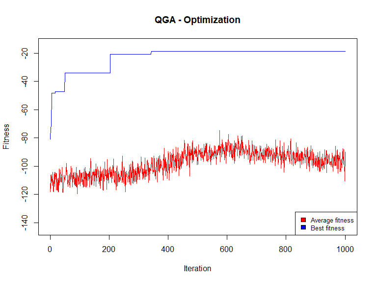

```r
QGA:::plot_Output(solutionQGA[[2]])
```

The plot indicates that the number of iterations was enough to obtain a solution that is likely to be no further improved.

### Analysis of the solution

```r
solution <- solutionQGA[[1]]
cities$city[solution]
```

```
#> [1] "Milan"    "Venice"   "Pescara"  "Naples"   "Rome"     "Florence" "Bologna"  "Genoa"    "Turin"
```

```r
cities_tsp <- cities[solution,]
```

The sum of distances:

```r
l = 0.0
for (i in 2:length(solution)) {
  l = l+distance[solution[i-1], solution[i]]
}
l = l + distance[solution[1],solution[length(solution)]]
l
```

```
#> [1] 18.57944
```

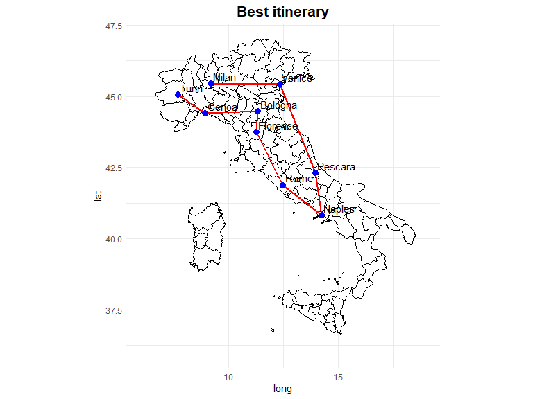

```r
# Plot
if (!require(maps)) install.packages("maps")
if (!require(tidyverse)) install.packages("tidyverse")
if (!require(ggplot2)) install.packages("ggplot2")
library(maps)
library(tidyverse)
library(ggplot2)
italy_map <- map_data("italy")
lines <- data.frame(
  x = cities_tsp$x[-nrow(cities_tsp)],
  y = cities_tsp$y[-nrow(cities_tsp)],
  xend = cities_tsp$x[-1],
  yend = cities_tsp$y[-1]
)
gg <- ggplot() +
  geom_polygon(data = italy_map, aes(x = long, y = lat, group = group),
               fill = "white", color = "black") +
  geom_segment(data = lines, aes(x = x, y = y, xend = xend, yend = yend),
               color = "red", size = 1) +
  geom_point(data = cities_tsp, aes(x = x, y = y), color = "blue", size = 3) +
  geom_text(data = cities_tsp, aes(x = x, y = y, label = city),
            hjust = 0, vjust = 0, nudge_x = 0.1, nudge_y = 0.1) +
  coord_fixed(1.3) +
  theme_minimal() +
  ggtitle("Best itinerary") +
  theme(plot.title = element_text(hjust = 0.5, size = 16, face = "bold")) +
  xlim(6, 19) + ylim(36, 47)
print(gg)
```

## Classical GA application

### Evaluation function

```r
evaluate <- function(solution) {
  solution <- round(solution)
  l = 0.0
  for (i in 2:length(solution)) {
    l = l+distance[solution[i-1], solution[i]]
  }
  l = l + distance[solution[1],solution[length(solution)]]
  penal <- ((nrow(distance)) - length(table(solution)))*sum(distance)/10
  cost <- penal+l
  return(cost)
}
```

### Optimization

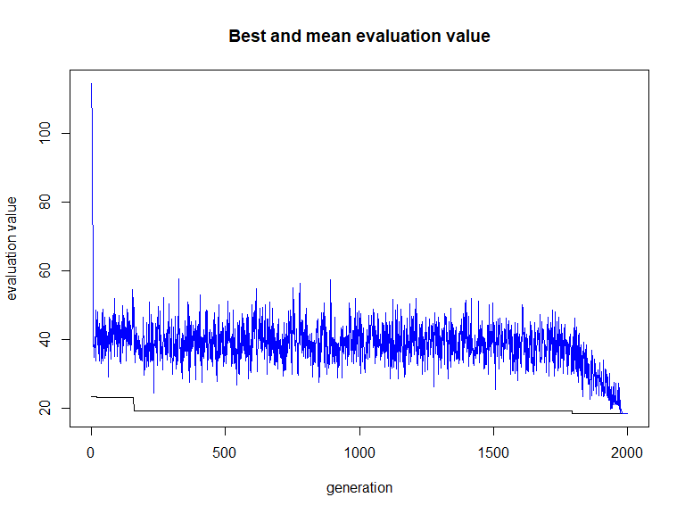

```r
set.seed(1234)
solutionGA <- rbga(stringMin=c(rep(1,nrow(cities))),
                     stringMax=c(rep(nrow(cities),nrow(cities))),
                     popSize=20,
                     iters=2000,
                     elitism=NA,
                     evalFunc=evaluate)
plot(solutionGA)
```

### Analysis of the solution

```r
filter = solutionGA$evaluations == min(solutionGA$evaluations)
bestObjectCount = sum(rep(1, solutionGA$popSize)[filter])
if (bestObjectCount > 1) {
  bestSolution = solutionGA$population[filter, ][1,
  ]
} else {
  bestSolution = solutionGA$population[filter, ]
}
bestSolution <- round(bestSolution)
cities$city[bestSolution]
```

```
#> [1] "Rome"     "Florence" "Genoa"    "Turin"    "Milan"    "Bologna"  "Venice"   "Pescara"  "Naples"
```

```r
cities_tsp <- cities[bestSolution,]
```

The sum of distances:

```r
l = 0.0
for (i in 2:length(bestSolution)) {
  l = l+distance[bestSolution[i-1], bestSolution[i]]
}
l = l + distance[bestSolution[1],bestSolution[length(bestSolution)]]
l
```

```
#> [1] 18.42261
```

The fitness of the GA solution is lower than the one by the QGA.

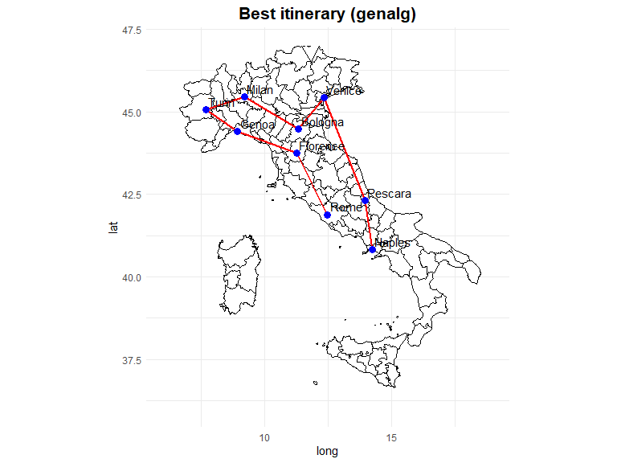

```r
italy_map <- map_data("italy")
lines <- data.frame(
  x = cities_tsp$x[-nrow(cities_tsp)],
  y = cities_tsp$y[-nrow(cities_tsp)],
  xend = cities_tsp$x[-1],
  yend = cities_tsp$y[-1]
)
gg <- ggplot() +
  geom_polygon(data = italy_map, aes(x = long, y = lat, group = group),
               fill = "white", color = "black") +
  geom_segment(data = lines, aes(x = x, y = y, xend = xend, yend = yend),
               color = "red", size = 1) +
  geom_point(data = cities_tsp, aes(x = x, y = y), color = "blue", size = 3) +
  geom_text(data = cities_tsp, aes(x = x, y = y, label = city),
            hjust = 0, vjust = 0, nudge_x = 0.1, nudge_y = 0.1) +
  coord_fixed(1.3) +
  theme_minimal() +
  ggtitle("Best itinerary (genalg)") +
  theme(plot.title = element_text(hjust = 0.5, size = 16, face = "bold")) +
  xlim(6, 19) + ylim(36, 47)
print(gg)
```

## Conclusions

In this case, the performance of the QGA is equivalent than the one of the classical GA (but the number of iterations of GA is the double).

Honestly, it has to be said that, increasing the number of the cities, GA outperforms QGA in the Traveller Salesman Problem.

In general, when the number of values that each element in the genome can assume is not high (in this case, we have 9 different values), then a relative efficiency of the QGA is to be expected. When the number of these values is higher, the classical GA tends to be more efficient.

In the particular case of the TSP, the greater length of the solution penalizes the QGA in the management of the solutions that present the same city more than once.